# LearningSpoonsR_lifeCountry

Geon Seung Lee

2019-01-14

## 1. 자료 불러오기

### 1-1. 폴더 만들기

C:/LS-DS/classProject라는 폴더를 만드세요.

### 1-3. 데이터셋 받기

[github](https://github.com/LearningSpoonsR/LS-DS/tree/master/classProject)에서 lifeCountry.csv 파일을 다운받아서 위 폴더에 넣으세요.  
이제 분석을 위한 모든 준비가 끝났습니다.

### 1-4. 데이터셋 R로 불러오기

실습데이터를 `dataset`으로 불러오도록 하겠습니다.

```r
dataset <- read.csv("lifeCountry.csv", stringsAsFactors = FALSE)
library(dplyr)
library(ggplot2)
```

## 2. 실습하기

### 2-1. 데이터는 총 몇개의 행과 열로 되어 있습니까?

데이터 구조 확인

```r
str(dataset)
```

```
## 'data.frame':    161 obs. of  11 variables:
##  $ X              : int  1 2 3 4 5 6 7 8 9 10 ...
##  $ Country        : chr  "Afghanistan" "Albania" "Algeria" "Angola" ...
##  $ ISO3           : chr  "AFG" "ALB" "DZA" "AGO" ...
##  $ Continent      : chr  "Asia" "Europe" "Africa" "Africa" ...
##  $ OECD_GDP       : num  NA NA NA NA NA ...
##  $ GDP_per_Capita : int  572 4520 4225 4401 16826 14061 3690 3690 56135 46435 ...
##  $ Population     : int  35530081 2930187 41318142 29784193 102012 44271041 2930450 2930450 24450561 8735453 ...
##  $ Life.Expectancy: num  60.5 77.8 75.6 52.4 76.4 76.3 74.8 74.8 82.8 81.5 ...
##  $ Female         : num  61.9 80.7 77.5 54 78.6 79.9 77.7 77.7 84.8 83.9 ...
##  $ Male           : num  59.3 75.1 73.8 50.9 74.1 72.7 71.6 71.6 80.9 79 ...
##  $ Health.Adjusted: num  52.2 68.8 66 45.8 67.5 67.6 66.8 66.8 71.9 72 ...
```

데이터는 총 161개의 행과 11개의 열로 이루어져 있습니다.

### 2-2. 가장 GDP가 높고 낮은 나라는 어디인가요? 가장 기대 수명이 길고 짧은 나라는 어디인가요?

가장 GDP가 높은 나라는 Luxembourg 입니다.  
**Luxembourg**의 Data는 아래와 같습니다.

```r
library(knitr)
library(kableExtra)
dataset %>% arrange(desc(GDP_per_Capita)) %>% head(1) %>% kable() %>% kable_styling(bootstrap_options = "striped", full_width = F, position = "left")
```

| X | Country | ISO3 | Continent | OECD_GDP | GDP_per_Capita | Population | Life.Expectancy | Female | Male | Health.Adjusted |
| --- | --- | --- | --- | --- | --- | --- | --- | --- | --- | --- |
| 90 | Luxembourg | LUX | Europe | 89067.29 | 107708 | 583455 | 82 | 84 | 79.8 | 71.8 |

가장 GDP가 낮은 나라는 South Sudan 입니다.  
**South Sudan**의 Data는 아래와 같습니다.

```r
dataset %>% arrange(GDP_per_Capita) %>% head(1) %>% kable() %>% kable_styling(bootstrap_options = "striped", full_width = F, position = "left")
```

| X | Country | ISO3 | Continent | OECD_GDP | GDP_per_Capita | Population | Life.Expectancy | Female | Male | Health.Adjusted |
| --- | --- | --- | --- | --- | --- | --- | --- | --- | --- | --- |
| 140 | South Sudan | SSD | Africa | NA | 221 | 12575714 | 57.3 | 58.6 | 56.1 | 49.9 |

가장 기대수명이 높은 나라는 Japan 입니다.  
**Japan**의 Data는 아래와 같습니다.

```r
dataset %>% arrange(desc(Life.Expectancy)) %>% head(1) %>% kable() %>% kable_styling(bootstrap_options = "striped", full_width = F, position = "left")
```

| X | Country | ISO3 | Continent | OECD_GDP | GDP_per_Capita | Population | Life.Expectancy | Female | Male | Health.Adjusted |
| --- | --- | --- | --- | --- | --- | --- | --- | --- | --- | --- |
| 76 | Japan | JPN | Asia | 38050.01 | 38550 | 127484450 | 83.7 | 86.8 | 80.5 | 74.9 |

가장 기대수명이 낮은 나라는 Sierra Leone 입니다.  
**Sierra Leone**의 Data는 아래와 같습니다.

```r
dataset %>% arrange(Life.Expectancy) %>% head(1) %>% kable() %>% kable_styling(bootstrap_options = "striped", full_width = F, position = "left")
```

| X | Country | ISO3 | Continent | OECD_GDP | GDP_per_Capita | Population | Life.Expectancy | Female | Male | Health.Adjusted |
| --- | --- | --- | --- | --- | --- | --- | --- | --- | --- | --- |
| 133 | Sierra Leone | SLE | Africa | NA | 593 | 7557212 | 50.1 | 50.8 | 49.3 | 44.4 |

### 2-3. 대륙별로 GDP와 기대수명의 평균을 구해보세요.

```r
dataset %>% group_by(Continent) %>% summarise(avg_GDP = mean(GDP_per_Capita), avg_LE = mean(Life.Expectancy)) %>% arrange(desc(avg_GDP)) %>% kable() %>% kable_styling(bootstrap_options = "striped", full_width = F, position = "left")
```

| Continent | avg_GDP | avg_LE |
| --- | --- | --- |
| Europe | 28589.325 | 78.39250 |
| Oceania | 13483.111 | 72.46667 |
| Asia | 13321.189 | 73.60000 |
| North America | 11175.105 | 74.52632 |
| South America | 8957.100 | 74.71000 |
| Africa | 2618.391 | 62.36522 |

### 2-4. 각 나라의 GDP를 X축으로, 기대수명을 Y축으로 산점도를 그리고 대륙에 따라서 점의 색깔이 달라지게 해보세요.

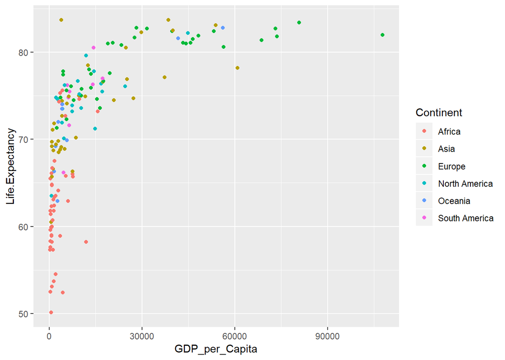

```r
ggplot(data = dataset, mapping = aes(x=GDP_per_Capita, y=Life.Expectancy))+
  geom_point(aes(color=Continent))
```

### 2-5. facet을 이용해서 대륙별로 GDP와 기대수명에 대한 산점도를 그려보세요.

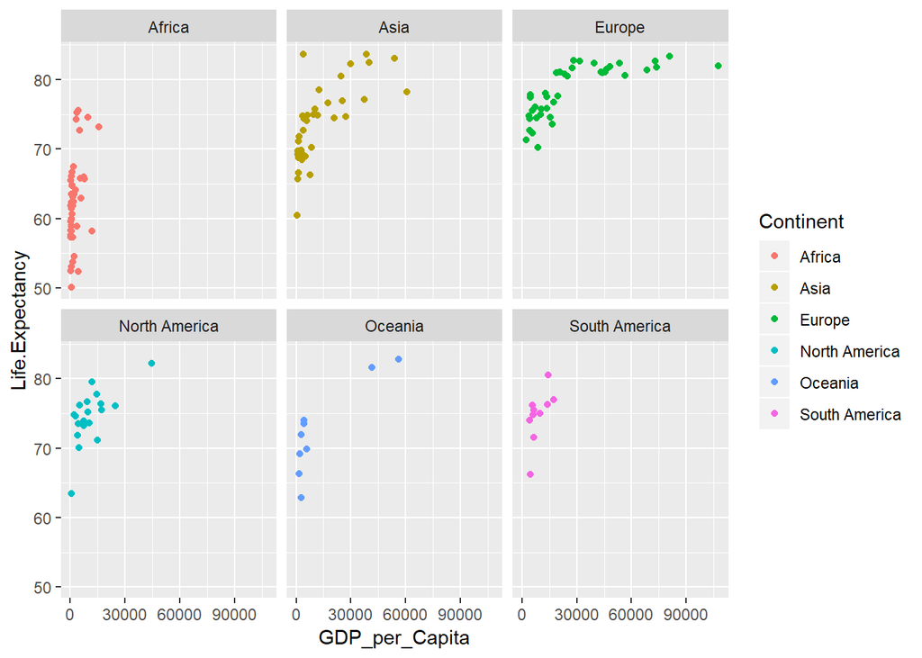

```r
a <- ggplot(data = dataset, mapping = aes(x=GDP_per_Capita, y=Life.Expectancy))+
  geom_point(aes(color=Continent))
a <- a+facet_wrap(~ Continent)
print(a)
```

### 2-6. 국가별로 성별에 따라 기대수명이 다릅니다. mutate 함수를 사용해서 ageSexDiff라는 변수를 만들어보세요.

```r
dataset<-dataset %>% mutate(ageSexDiff = abs(Female-Male))
dataset %>% arrange(desc(ageSexDiff)) %>% head()
```

```
##     X   Country ISO3 Continent OECD_GDP GDP_per_Capita Population
## 1  17   Belarus  BLR    Europe       NA           5585    9468338
## 2  89 Lithuania  LTU    Europe 28116.83          16443    2890297
## 3 124    Rwanda  RWA    Africa       NA            754   12208407
## 4 158   Ukraine  UKR    Europe       NA           2458   44222947
## 5  84    Latvia  LVA    Europe 24243.70          15402    1949670
## 6  49   Estonia  EST    Europe 27929.45          19618    1309632
##   Life.Expectancy Female Male Health.Adjusted ageSexDiff
## 1            72.3   78.0 66.5            65.1       11.5
## 2            73.6   79.1 68.1            66.0       11.0
## 3            66.1   71.1 60.9            56.6       10.2
## 4            71.3   76.1 66.3            64.1        9.8
## 5            74.6   79.2 69.6            67.1        9.6
## 6            77.6   82.0 72.7            68.9        9.3
```

### 2-7. 어떤 대륙에서 ageSexDiff가 가장 크고 작은가요?

```r
dataset %>% group_by(Continent) %>% summarise(avg_ageSexDiff=mean(ageSexDiff)) %>% arrange(desc(avg_ageSexDiff))
```

```
## # A tibble: 6 x 2
##   Continent     avg_ageSexDiff
##   <chr>                  <dbl>
## 1 Europe                  6.00
## 2 South America           5.97
## 3 North America           5.52
## 4 Asia                    4.86
## 5 Oceania                 4.71
## 6 Africa                  3.72
```

## 3. 자유로운 분석

### 3-1. 인구를 포함하여 X축에 GDP, Y축에 기대수명으로 버블차트를 만들어보세요.

“각 국가 인구별 GDP/기대수명”

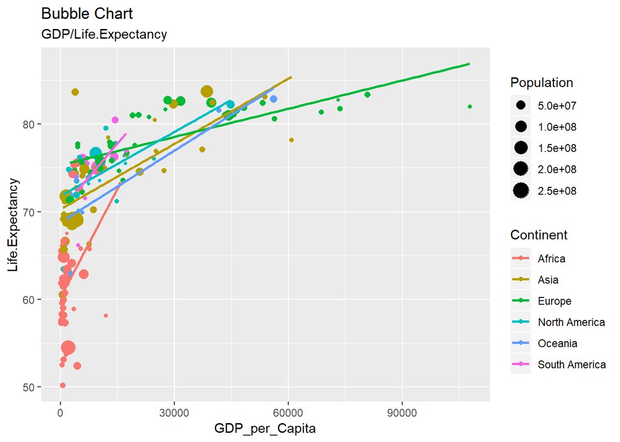

```r
b<- ggplot(dataset, mapping = aes(x=GDP_per_Capita, y=Life.Expectancy))+
  labs(subtitle = "GDP/Life.Expectancy",
       title= "Bubble Chart")
b + geom_jitter(aes(col=Continent, size=Population)) +
  geom_smooth(aes(col=Continent), method="lm", se=F)
```